# Module IV. Statistical Inference, part II.

```r
# install.packages("MASS") - run this code if you do not have MASS package
library(MASS)
```

## 1. Sample size for estimating the population mean and proportion.

### 1.1. How the sample size affects the confidence interval, or How to choose the sample size *n* to obtain the margin of error *m* for a population mean *mu* at a desired confidence level.

**Assumptions**: The population has the *N(mu,sigma)* (normal) distribution with known mean and variance.

**Formula**: The sample mean *x'* from the *N(mu,sigma)* distribution has a normal distribution *N(mu,sigma/sqrt(n))*.  
A level *C* confidence interval for a population mean *mu* is *[x' - m; x' + m ]*, where *x'* is a sample mean.  
The margin of error for *mu* is *m = z*sigma/sqrt(n)*, where z is a critical value for the z distribution *N(0,1)* such that the area between -z and z is equal to *C*.

C = 90% z = 1.645  
C = 95% z = 1.960  
C = 99% z = 2.576

How to obtain z at a specified C:

```r
C <- 0.5
qnorm(C) #gives a value z such that P(X < z) = C
```

```
## [1] 0
```

```r
#to find z for the interval in between -z and z
C <- 0.9
qnorm(C + (1-C)/2) #gives a value of z such that P(-z < X < z) = C
```

```
## [1] 1.644854
```

**Q1.1.** Find the critical values -z and z for the area under the standard normal curve of 99.99%

**Q1.2.** The average credit card balance for a random sample of 1200 graduates was $3173, with the median of $1645 and sigma of $3500. Is this sample comes from the normal distribution?

How to compute the 95% confidence interval for the population mean.

```r
z <- qnorm(0.975)
sigma <- 3500
n <- 1200
m <- z*sigma/sqrt(n) #margin of error

sample_mean <- 3173
left_interval <- sample_mean - m
right_interval <- sample_mean + m
```

The 95% confidence interval for the average (mean) credit card debt for all graduates is between $2975 and $3371.

Let's draw it in a graph.

```r
plot(sample_mean,2,xlim=c(2500,4000),ylim=c(0,12),axes=F)
axis(1)
segments(left_interval, 2, right_interval, 2, lwd=4)
```

[output not shown]

**Q1.3.** Compute and draw the 90%, 99% and 99.9% confidence intervals for the population mean from the sample of Q2. How does the interval change when confidence increases?

```r
sample_mean <- 3173
sigma <- 3500
n <- 1200

m90 <- qnorm(0.95) * sigma/sqrt(n) #margin of error for the 90% confidence interval
m99 <- qnorm(0.995) * sigma/sqrt(n) #margin of error for the 99% confidence interval
m999 <- qnorm(0.9995) * sigma/sqrt(n) #margin of error for the 99.9% confidence interval

left_interval <- sample_mean - m90
right_interval <- sample_mean + m90
y <- 1
points(sample_mean, y)
segments(left_interval, y, right_interval, y, lwd=4)

left_interval <- sample_mean - m99
right_interval <- sample_mean + m99
y <- 3
points(sample_mean, y)
segments(left_interval, y, right_interval, y, lwd=4)

left_interval <- sample_mean - m999
right_interval <- sample_mean + m999
y <- 4
points(sample_mean, y)
segments(left_interval, y, right_interval, y, lwd=4)
```

**Q1.4.** Compute and draw the 90%, 95%, 99% and 99.9% confidence interval for the population mean from the sample of Q2, but with n=300. How do the intervals change in comparison with n=1200?

```r
sample_mean <- 3173
sigma <- 3500
n <- 300

m90 <- qnorm(0.95) * sigma/sqrt(n) #margin of error for the 90% confidence interval
m95 <- qnorm(0.975) * sigma/sqrt(n) #margin of error for the 95% confidence interval
m99 <- qnorm(0.995) * sigma/sqrt(n) #margin of error for the 99% confidence interval
m999 <- qnorm(0.9995) * sigma/sqrt(n) #margin of error for the 99.9% confidence interval

left_interval <- sample_mean - m90
right_interval <- sample_mean + m90
y <- 5
points(sample_mean, y)
segments(left_interval, y, right_interval, y, lwd=4, col="red")

left_interval <- sample_mean - m95
right_interval <- sample_mean + m95
y <- 6
points(sample_mean, y)
segments(left_interval, y, right_interval, y, lwd=4, col="red")

left_interval <- sample_mean - m99
right_interval <- sample_mean + m99
y <- 7
points(sample_mean, y)
segments(left_interval, y, right_interval, y, lwd=4, col="red")

left_interval <- sample_mean - m999
right_interval <- sample_mean + m999
y <- 8
points(sample_mean, y)
segments(left_interval, y, right_interval, y, lwd=4, col="red")
```

**Q1.5.** Compute the 90%, 95%, 99%, and 99.9% confidence intervals for the population mean from the sample of Q2, but with smaller sigma=$2000, n=1200.

```r
sample_mean <- 3173
sigma <- 2000
n <- 1200

m90 <- qnorm(0.95) * sigma/sqrt(n) #margin of error for the 90% confidence interval
m95 <- qnorm(0.975) * sigma/sqrt(n) #margin of error for the 95% confidence interval
m99 <- qnorm(0.995) * sigma/sqrt(n) #margin of error for the 99% confidence interval
m999 <- qnorm(0.9995) * sigma/sqrt(n) #margin of error for the 99.9% confidence interval

left_interval <- sample_mean - m90
right_interval <- sample_mean + m90
y <- 9
points(sample_mean, y)
segments(left_interval, y, right_interval, y, lwd=4, col="blue")

left_interval <- sample_mean - m95
right_interval <- sample_mean + m95
y <- 10
points(sample_mean, y)
segments(left_interval, y, right_interval, y, lwd=4, col="blue")

left_interval <- sample_mean - m99
right_interval <- sample_mean + m99
y <- 11
points(sample_mean, y)
segments(left_interval, y, right_interval, y, lwd=4, col="blue")

left_interval <- sample_mean - m999
right_interval <- sample_mean + m999
y <- 12
points(sample_mean, y)
segments(left_interval, y, right_interval, y, lwd=4, col="blue")
```

#### Other things being equal, the margin of error of a confidence interval decreases as

#### * the confidence level *C* decreases,

#### * the sample size *n* increases, and

#### * the population standard deviation *sigma* decreases.

#### How to lower the margin of error of the population mean? The choices are:

#### * Lower the level of confidence *C*.

#### * Increase the sample size *n*.

#### * Reduce the population variance *sigma*.

**Q1.6.** If we are designing the survey for the estimation of the average credit card debt among graduates as in Q2 (sigma = $3500) and want the margin of error to be $150 with 95% confidence, what sample size *n* do we need?

```r
sigma <- 3500
m <- 150
z <- qnorm(0.975)

n <- (z * sigma / m) ^2
```

#### If the population standard deviation *sigma* is unknown (which is usually the case), for a large sample (n > 40), the sample standard deviation *s* can be used to approximate *sigma*. For a small sample, the bootsrap procedure (resampling with replacement) can be used.

### 1.2. Proportions. How to choose the sample size *n* to obtain the margin of error *m* for a population proportion *p* at a desired level *C* confidence interval *[p-m; p+m]*.

**Assumptions**: When *n* is large, sample proprtion *p'* has a Normal distribution with mean *p* and standard deviation *sqrt(p(1-p)/n)*.

**Formula**: *n = (z/m)<sup>2</sup> *p(1-p)* where *p* is a guessed value for the proportion. The margin of error *m* is the largest when *p=0.5*, therefore it can be used to obtain a very conservative estimation of the sample size (larger than might be needed).

**Q1.7.** You design a survey assessing the proportion of people satisfied versus unsatisfied with some organizational policy. At 95% confidence and a margin of error <= 5% find the required sample size *n* (always round up *n*).

```r
p <- 0.5
m <- 0.05
z <- qnorm(0.975)

n <- (z/m)^2 * p * (1-p)
```

**Q1.8.** Find *n* at *m <= 3%* and *m <= 1%*.

**Q1.9.** In the above problem, how will *n* change if a preliminary study gave *p'=0.2* and we want *m <= 5%*?

**Q1.10.** Build a graph showing how the margin error of a 95% confidence interval *m* depends on *p* at different *n*.

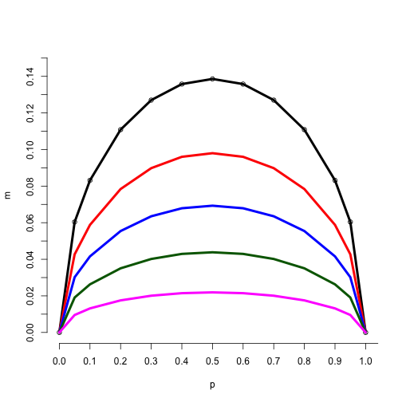

```r
z <- qnorm(0.975)
p <- c(0, 0.05, 0.1, 0.2, 0.3, 0.4, 0.5, 0.6, 0.7, 0.8, 0.9, 0.95, 1)

n <- 50
m <-  z * sqrt(p*(1-p)/n)
plot(p,m, xlim=c(0,1.0), ylim=c(0,0.15), axes=F)
axis(1, at = seq(0, 1.1, by = 0.1))
axis(2, at = seq(0, 0.15, by = 0.01))
lines(p,m, lwd=4)

n <- 100
m <-  z * sqrt(p*(1-p)/n)
lines(p,m, lwd=4, col="red")

n <- 200
m <-  z * sqrt(p*(1-p)/n)
lines(p,m, lwd=4, col="blue")

n <- 500
m <-  z * sqrt(p*(1-p)/n)
lines(p,m, lwd=4, col="darkgreen")

n <- 2000
m <-  z * sqrt(p*(1-p)/n)
lines(p,m, lwd=4, col="magenta")
```

## 2. Power of tests.

### 2.1. Types of errors.

#### Type I error occures when we reject H0 when in fact it is true. Type I error rate, alpha (or significance level), is a probability to reject H0 when it is true.

#### Type II error occures is when we do not reject H0 when in fact it is false. Type II error rate, beta, is a probability to fail to reject H0 when it is not true.

#### Power = 1- beta. The power of the test to detect Ha is the probability that a fixed level alpha significance test will reject H0 when Ha is true.

#### The power of a statistical test measures its ability to detect deviations from the null hypothesis.

#### In practice, the test is performed to show that H0 is false, so high (>80%) power is important.

“What we actually call type I or type II error depends directly on the null hypothesis. Negation of the null hypothesis causes type I and type II errors to switch roles.  
The goal of the test is to determine if the null hypothesis can be rejected. A statistical test can either reject or fail to reject a null hypothesis, but never prove it true.” (Wikipedia)

### 2.2. The power of the one-sample t test.

Reminder: One-sample t test is used for inference about the population mean *mu* based on the sample mean *x'*, assuming that the distribution is normal and its standard deviation *sigma* is known or can be estimated from the sample standard deviation *s*. Two-sample t test is used for inference about difference in two populaions means.

If n >= 40, the t test is suitable even for skewed distributions.  
If n >=15, no outliers and slight skewedness are acceptable.  
If n < 15, t test can be used for a normally distributed data with no outliers.

**Q2.1.** The effect of a treatment was tested on 20 subjects (some parameter W was measured before and after treatment). Its average difference was x' = 2.43 and standard deviation was s = 1.46 (for a safe estimate it is recommended to round it up, let's take s = 1.5).  
The hypothesis to test is H0: mu = 0. Ha: mu > 0 WHEN THE ALTERNATIVE is mu=1.0. At alpha = 0.05.

The t test with n observations rejects H0 at the 5% significance level if the t statistic *t = ( x' - 0) / (s/sqrt(n))* exceeds the critical value for the t-distribution at df=19 (= n-1).

```r
qt(c(0.25, .975), df=19) # two-sided
```

```
## [1] -0.6876215  2.0930241
```

```r
t <- abs(qt(0.95,df=19)) # one-sided
t
```

```
## [1] 1.729133
```

The event that the test rejects H0 happens when *x' / (s / sqrt(n) ) >= t*.

```r
n <- 20
s <- 1.5
x <- t*s/sqrt(n)
```

The power is a probability that x' >= x when mu = 1.0. P( [ (x'-1.0) /1.5/sqrt(20)] >= [ (x-1.0) /1.5/sqrt(20) ] ) = P( Z >= -1.25 )

```r
power <- 1 - pnorm(-1.25)
power
```

```
## [1] 0.8943502
```

This is the power that we will detect an increase in the measured parameter W of 1.0.

**Q2.2.** If the sample size is increased at n=100, what will be the power of the test to detect an alternative increase of W of 1.0 (same as in Q2.1)?

```r
n <- 100
t <- abs(qt(0.95,df=n-1)) # one-sided
s <- 1.5
x <- t*s/sqrt(n)
muu <- 1.0
z <- (x - muu) / ( s / sqrt(n))
power <- 1 - pnorm(z)
```

**Q2.3.** With n=100 at 5% of significance level and power of 95%, what increase of the parameter W can be detected?

```r
power <- 0.95
z <- qnorm(1 - power)

muu <- x - z * (s / sqrt(n))
```

### 2.3. The power of the two-sample t test.

**Q2.4.** The experiment was carried out to study if calcium intake reduced blood pressure. The calcium treated group consisted of n1=10 subjects, with measurements for the average dicrease in blood pressure x1=5.000, s1=8.743. The placebo group: n2=11, x2=-0.273, s2=5.901. Both samples satisfied normal distribution and had no outliers (the assumptions to carry out the t-test for n < 15). The pooled sample standard deviation was s = 7.385. The P-value was 0.059, meaning that there was no enough evidence to reject the null hypothesis that calcium intake did not lower blood pressure.

Now a new experiment is planned that would provide convincing evidence for calcium intake, at the 1% of significance level for the alternative difference in means of 5.0. Sizes of both groups have been increased to 45: n1=45, n2=45. What is the power of this test?

```r
n1 <- 45
n2 <- 45
s <- 7.385 #the pooled sample standard deviation
muu <- 5.0 #the alternative difference in means
df <- n1 + n2 - 2 # the degrees of freedom
alpha <- 0.01

delta <- muu / (s * sqrt( (1/n1) + (1/n2) )) # the non-centrality parameter
t <- abs(qt(1 - alpha, df=df)) # one-sided critical value of t distribution

power <- 1 - pt(t, df, delta)
```

**Q2.5.** How would the power of the above test change at the 5% of significance and reduced size of groups, n1 = n2 = 30?

[output not shown]

#### Calculating power using the package “pwr”

(from http://www.ats.ucla.edu/stat/r/dae/t_test_power3.htm)

**Q2.6.** “A company markets an eight week long weight loss program and claims that at the end of the program on average a participant will have lost 5 pounds. On the other hand, you have studied the program and you believe that their program is scientifically unsound and shouldn't work at all. With some limited funding at hand, you want test the hypothesis that the weight loss program does not help people lose weight. Your plan is to get a random sample of people and put them on the program. You will measure their weight at the beginning of the program and then measure their weight again at the end of the program. Based on some previous research, you believe that the standard deviation of the weight difference over eight weeks will be 5 pounds. You now want to know how many people you should enroll in the program to test your hypothesis. ”

```r
#install.packages("pwr")
library(pwr)

mu_0 <- 0 # mu for H0
mu_a <- 5 # mu for Ha
s <- 5 # standard deviation for the difference in means
power <- 0.8
alpha <- 0.05

d <- (mu_0 - mu_a) / s # this is the standard effect size

#calculates sample size n
test <- pwr.t.test(d=d,power=power,sig.level=alpha,type="paired",alternative="two.sided")
test
```

```
##
##      Paired t test power calculation
##
##               n = 9.93785
##               d = 1
##       sig.level = 0.05
##           power = 0.8
##     alternative = two.sided
##
## NOTE: n is number of *pairs*
```

```r
#n is
test$n
```

```
## [1] 9.93785
```

```r
#calculates power for a given sample size n
n <- 35
test <- pwr.t.test(d=d,n=n,sig.level=alpha,type="paired",alternative="two.sided")
#power
test$power
```

```
## [1] 0.9999224
```

**Q2.7.** For the above experiment, calculate *n* for power = 0.95, s = 10 and alpha=0.00001

**Q2.8.** For the above experiment, draw power curves (power vs. effect size) for different n = (5,15,25,35,45).

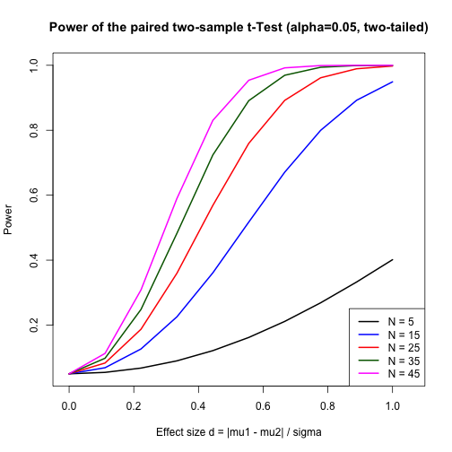

```r
n <- seq(5, 50, by=10)
alpha <- 0.05
ds <- seq(0, 1, length.out=10)     # effect sizes d for t-Test

get_power <- function(n){
  test <- pwr.t.test(d=ds,n=n,sig.level=alpha,type="paired",alternative="two.sided")
  test$power
}
ps <- sapply(n, get_power)

par(mfrow = c(1,1))
colors <- c("black", "blue", "red", "darkgreen", "magenta")
matplot(ds, ps, type="l", lty=1, lwd=2, xlab="Effect size d = |mu1 - mu2| / sigma", ylab="Power", main="Power of the paired two-sample t-Test (alpha=0.05, two-tailed)", xaxs="i", xlim=c(-0.05, 1.1), col=colors)
legend(x="bottomright", legend=paste("N =", n), lwd=2, col= colors)
```

**Q2.9.** Solve in R Problem 3.4 from the Lecture 4.

```r
alpha <- 0.05
d <- 2/20
power <- 0.85

pwr.t.test(d=d,power=power,sig.level=alpha,type="paired",alternative="greater")
```

```
##
##      Paired t test power calculation
##
##               n = 720.2848
##               d = 0.1
##       sig.level = 0.05
##           power = 0.85
##     alternative = greater
##
## NOTE: n is number of *pairs*
```

## 3. Tests on Normality of the distirbution and data transformation.

### 3.1. Tests for normality.

Let's examine a randomly generated sample from a normal distribution.

```r
set.seed(42)
x <- rnorm(100)

shapiro.test(x)
```

```
##
##  Shapiro-Wilk normality test
##
## data:  x
## W = 0.98122, p-value = 0.1654
```

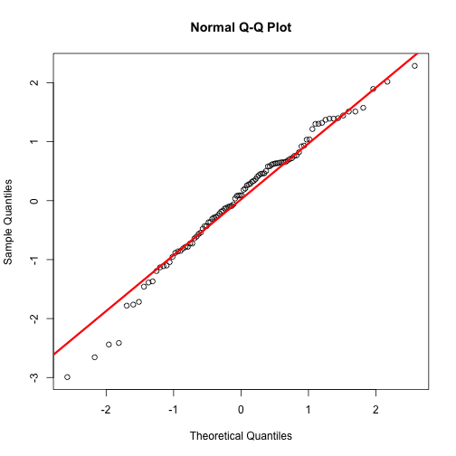

```r
qqnorm(x)
qqline(x, col = "red", lwd=3)
```

**Q3.1.** Repeat the above procedure for the sample of size 10000 with mu=3 and sigma = 2.

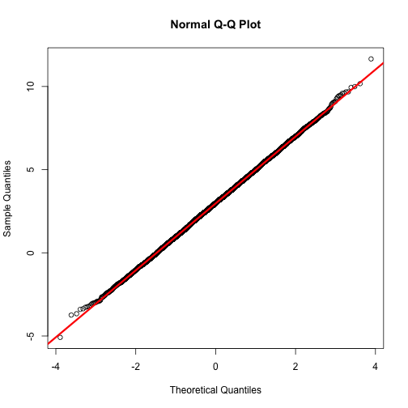

```r
set.seed(42)
x <- rnorm(10000, mean = 3, sd = 2)
qqnorm(x)
qqline(x, col = "red", lwd=3)
```

```r
shapiro.test(x)
```

```
## Error in shapiro.test(x): sample size must be between 3 and 5000
```

#### Kolmogorov-Smirnov test for normality.

```r
ks.test(x,"pnorm",mean(x),sqrt(var(x)))
```

```
##
##  One-sample Kolmogorov-Smirnov test
##
## data:  x
## D = 0.0060756, p-value = 0.8541
## alternative hypothesis: two-sided
```

#### Other tests

```r
#install.packages("moments")
library(moments)

# skewness and kurtosis, they should be around 0 and 3
skewness(x)
```

```
## [1] 0.00601486
```

```r
kurtosis(x)
```

```
## [1] 2.99009
```

```r
#install.packages("car")
library(car)
```

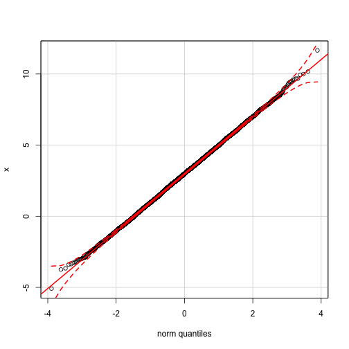

```r
#qqplot with confidence interval
qqPlot(x)
```

**Q3.2.** Test normality of random samples of size 100 taken from a Gamma distribution; use rgamma(n, shape, scale), for shape = 1, 2, and scale = 1, 2.

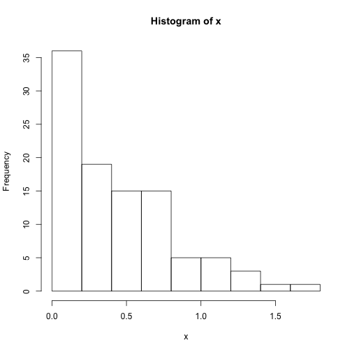

```r
shape <- 1
scale <- 2
x <- rgamma(100, shape, scale)
hist(x)
```

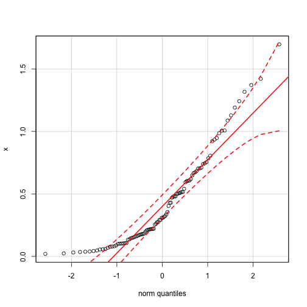

```r
qqPlot(x) #library(car)
```

```r
skewness(x)
```

```
## [1] 1.118146
```

```r
kurtosis(x)
```

```
## [1] 3.713509
```

```r
shapiro.test(x)
```

```
##
##  Shapiro-Wilk normality test
##
## data:  x
## W = 0.88468, p-value = 2.879e-07
```

**Q3.3.** Log-tranformation of right-skewed data (long right tail; positive skewness). Do log-transformation (try log, log10, log2) of a gamma-sample (3,2) and run normality tests on transformed data. Which transformation was the best taking into account the Shapiro test? Looking at qqPlot(x)?

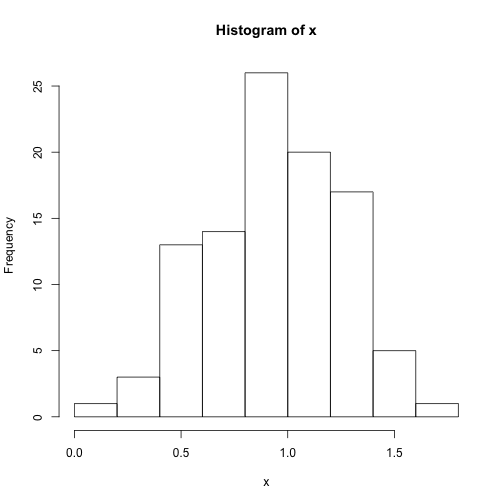

```r
shape <- 3
scale <- 2
x <- rgamma(100, shape, scale)

x <- log(x + 1) # try also log10, log2

hist(x)
```

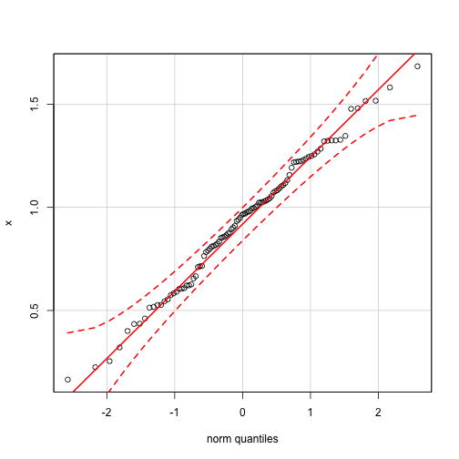

```r
qqPlot(x) #library(car)
```

```r
skewness(x)
```

```
## [1] -0.1056408
```

```r
kurtosis(x)
```

```
## [1] 2.623482
```

```r
shapiro.test(x)
```

```
##
##  Shapiro-Wilk normality test
##
## data:  x
## W = 0.99124, p-value = 0.764
```

#### Optimal log-transformation can be found as follows:

```r
#install.packages("e1071")
library(e1071)
library(datasets)

data(airquality)

par(mfrow = c(3,1))

x <- airquality$Ozone
x <- x[!is.na(x)]
skewness(x)
```

```
## [1] 1.209866
```

```r
hist(x)
shapiro.test(x)
```

```
##
##  Shapiro-Wilk normality test
##
## data:  x
## W = 0.87867, p-value = 2.79e-08
```

```r
ks.test(x,"pnorm",mean(x),sqrt(var(x)))
```

```
##
##  One-sample Kolmogorov-Smirnov test
##
## data:  x
## D = 0.14799, p-value = 0.01243
## alternative hypothesis: two-sided
```

```r
y1 <- log(x+1)
skewness(y1)
```

```
## [1] -0.320222
```

```r
hist(y1)
shapiro.test(y1)
```

```
##
##  Shapiro-Wilk normality test
##
## data:  y1
## W = 0.98199, p-value = 0.1219
```

```r
ks.test(y1,"pnorm",mean(y1),sqrt(var(y1)))
```

```
##
##  One-sample Kolmogorov-Smirnov test
##
## data:  y1
## D = 0.06415, p-value = 0.7263
## alternative hypothesis: two-sided
```

```r
skew.score <- function(c, x) (skewness(log(x + c)))^2
coef <- optimise(skew.score, c(0, 20), x = x)$minimum
y2 <- log(x + coef)

skewness(y2)
```

```
## [1] -4.930632e-08
```

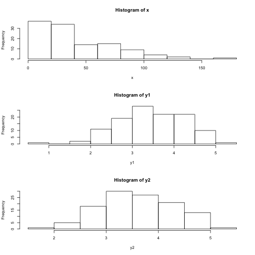

```r
hist(y2)
```

```r
shapiro.test(y2)
```

```
##
##  Shapiro-Wilk normality test
##
## data:  y2
## W = 0.98504, p-value = 0.2263
```

```r
ks.test(y2,"pnorm",mean(y2),sqrt(var(y2)))
```

```
##
##  One-sample Kolmogorov-Smirnov test
##
## data:  y2
## D = 0.074619, p-value = 0.5382
## alternative hypothesis: two-sided
```

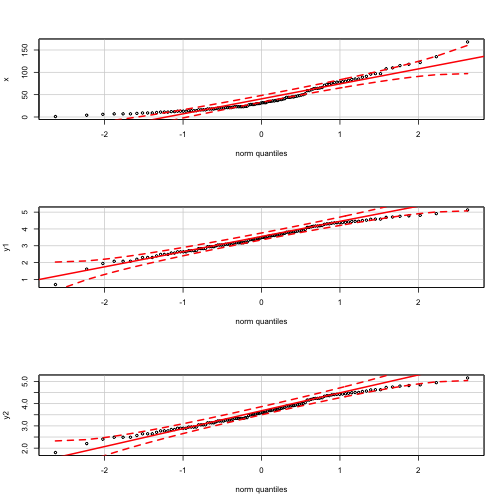

```r
qqPlot(x)
qqPlot(y1)
qqPlot(y2)
```

```r
par(mfrow = c(1,1))
```

#### Power transformation for left-skewed data (long left tail)

```r
x <- c(8.11, 8.11, 8.09, 8.08, 8.06, 8.02, 7.99, 7.99, 7.97, 7.95, 7.92, 7.92, 7.92, 7.89, 7.87, 7.84, 7.79, 7.79, 7.77, 7.76, 7.72, 7.71, 7.66, 7.62, 7.61, 7.59, 7.55, 7.53, 7.50, 7.50, 7.42, 7.38, 7.38, 7.26, 7.25, 7.08, 6.96, 6.84, 6.55) # London Olympic 2012, men jumps

par(mfrow = c(3,1))

skewness(x)
```

```
## [1] -1.052988
```

```r
hist(x)
shapiro.test(x)
```

```
##
##  Shapiro-Wilk normality test
##
## data:  x
## W = 0.90884, p-value = 0.003995
```

```r
ks.test(x,"pnorm",mean(x),sqrt(var(x)))
```

```
##
##  One-sample Kolmogorov-Smirnov test
##
## data:  x
## D = 0.11491, p-value = 0.6817
## alternative hypothesis: two-sided
```

```r
y1 <- x^2
skewness(y1)
```

```
## [1] -0.9371294
```

```r
hist(y1)
shapiro.test(y1)
```

```
##
##  Shapiro-Wilk normality test
##
## data:  y1
## W = 0.92177, p-value = 0.009872
```

```r
ks.test(y1,"pnorm",mean(y1),sqrt(var(y1)))
```

```
##
##  One-sample Kolmogorov-Smirnov test
##
## data:  y1
## D = 0.10755, p-value = 0.7578
## alternative hypothesis: two-sided
```

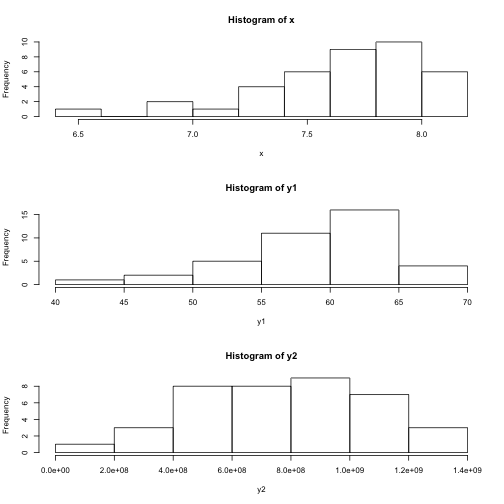

```r
y2 <- x^10
hist(y2)
```

```r
shapiro.test(y2)
```

```
##
##  Shapiro-Wilk normality test
##
## data:  y2
## W = 0.96987, p-value = 0.3721
```

```r
ks.test(y2,"pnorm",mean(y2),sqrt(var(y2)))
```

```
##
##  One-sample Kolmogorov-Smirnov test
##
## data:  y2
## D = 0.089004, p-value = 0.9168
## alternative hypothesis: two-sided
```

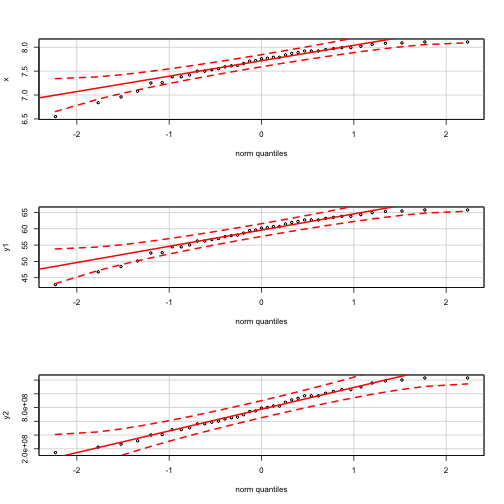

```r
qqPlot(x)
qqPlot(y1)
qqPlot(y2)
```

```r
par(mfrow = c(1,1))
```

#### Poisson distribution (count data). Do not transform! Use suitable models, e.g., Poisson regression.

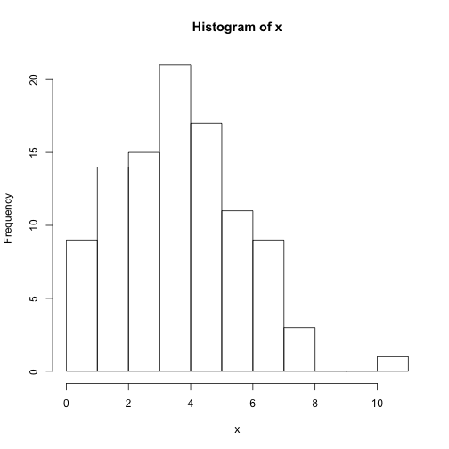

```r
lambda <- 4
x <- rpois(100, lambda)

hist(x)
```

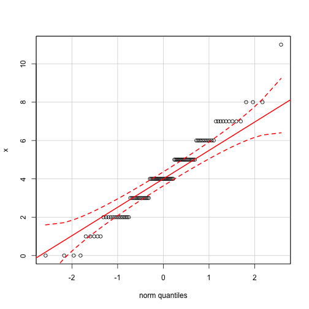

```r
qqPlot(x) #library(car)
```

See also http://stats.stackexchange.com/questions/101274/how-to-interpret-a-qq-plot?rq=1

## 4. Non-parametric tests (distribution-free tests: no assumption on the population distribution or sample size).

### Non-parametric tests are for testing medians, while parametric, means.

### Non-parametric tests corresponding to parametric tests:

#### One-sample t test or z test <–> One-sample Sign test (non-symmetric distribution); One-sample Wilcoxon test (symmetric distribution)

#### Two sample t test <–> Paired sample: Wilcoxon signed-rank test, wilcox.test(x,y, paired=TRUE); Mann-Whitney test on ranks, wilcox.test(x,y).

#### ANOVA <–> Kruskal_Wallis test , Mood's median test, and Friedman test

### Reasons to use parametric tests vs. non-parametric

(adapted from http://blog.minitab.com/blog/adventures-in-statistics/choosing-between-a-nonparametric-test-and-a-parametric-test and http://blog.minitab.com/blog/statistics-and-quality-data-analysis/truth-beauty-nonparametrics-and-symmetry-plots):

#### (1) They suitable for samples 15 =< n <= 40 of skewed data with no outliers.

#### And for two samples even if the variances are different (by default t.test() assumes unequal variances).

#### (2) They have greater power – larger probability to reject H0 when Ha is in fact true, – that can be estimated.

### Reasons to use non-parametric tests:

#### (1) Data are better represented by the median rather than the mean.

#### (2) A very small sample size.

#### (3) Many outliers, ordinal data, ranked data.

#### (4) Data cannot be transformed (or no need to transform them)

### 4.1. Sign test (one sample, non-symmetrical distrbution).

Problem 4.6 of the lecture (10 patients, 5 reduced weight, 3 gained). Do these data suggest that the weight-control treatment works (that is, can we reject the null hypothesis that there is no difference in patients' weight between before and after treatment?

```r
#install.packages("BSDA")
library(BSDA)
```

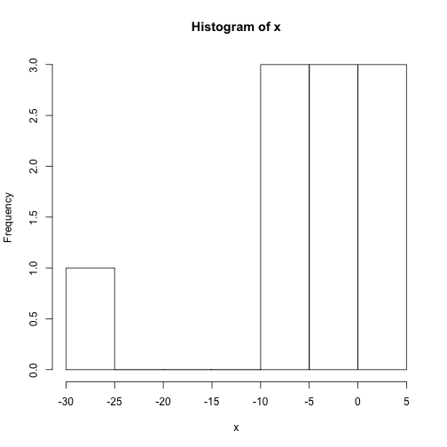

```r
x1 <- c(200,202,194,188,166,196,180,188,180,210)
x2 <- c(202,204,167,192,166,190,176,182,180,202)
x <- x2 - x1
hist(x)
```

```r
size <- length(x)
win <- sum(x<0)

p <- 1 - pbinom(win, size, p=0.5)
SIGN.test(x, md=0, alternative = "less")
```

```
##
##  One-sample Sign-Test
##
## data:  x
## s = 3, p-value = 0.3633
## alternative hypothesis: true median is less than 0
## 95 percent confidence interval:
##  -Inf    2
## sample estimates:
## median of x
##          -2
```

```
##                   Conf.Level L.E.pt U.E.pt
## Lower Achieved CI     0.9453   -Inf      2
## Interpolated CI       0.9500   -Inf      2
## Upper Achieved CI     0.9893   -Inf      2
```

There is no enough evidence to reject H0.

**Q4.1.** Test H0 that the weight in group x1 is above 180 pounds. Do we have enough evidence to reject this H0?

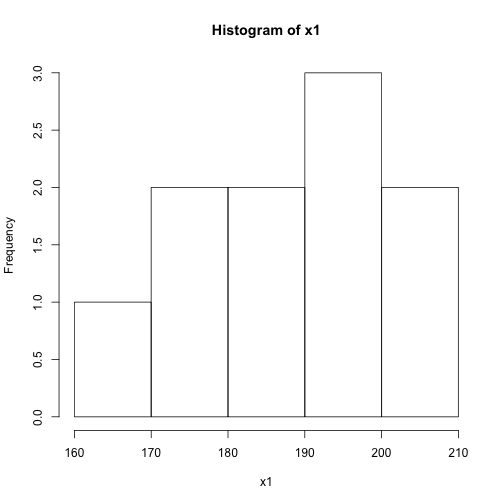

```r
hist(x1)
```

```r
size <- length(x1)
win <- sum(x1 > 180)

p <- pbinom(win, size, p=0.5)
SIGN.test(x1 - 180, md=0, alternative = "less")
```

```
##
##  One-sample Sign-Test
##
## data:  x1 - 180
## s = 7, p-value = 0.9961
## alternative hypothesis: true median is less than 0
## 95 percent confidence interval:
##      -Inf 20.21333
## sample estimates:
## median of x
##          11
```

```
##                   Conf.Level L.E.pt  U.E.pt
## Lower Achieved CI     0.9453   -Inf 20.0000
## Interpolated CI       0.9500   -Inf 20.2133
## Upper Achieved CI     0.9893   -Inf 22.0000
```

**Q4.2.** Test H0 that the weight in group x2 is below 167 pounds. Do we have enough evidence to reject this H0?

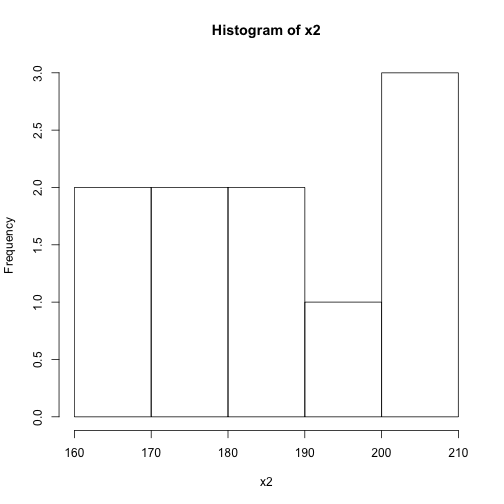

[output not shown]

```
##                   Conf.Level L.E.pt U.E.pt
## Lower Achieved CI     0.9453     13    Inf
## Interpolated CI       0.9500     13    Inf
## Upper Achieved CI     0.9893     13    Inf
```

**Q4.3.** Test H0 that the median of weight difference is 0. For this two-sided test, the null hypothesis is that the number of + and - signs are equal, and the alternative hypothesis is that the number of + and - signs are not equal. Do we have enough evidence to reject this H0?

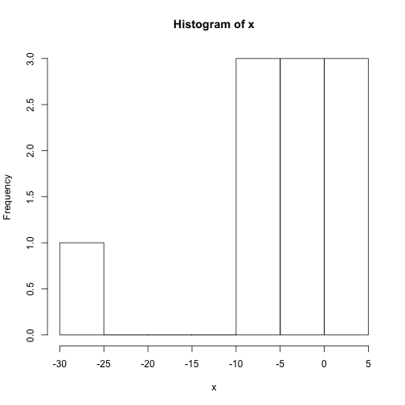

```r
hist(x)
```

```r
median <- 0
SIGN.test(x - median, md=0, alternative = "two.sided")
```

```
##
##  One-sample Sign-Test
##
## data:  x - median
## s = 3, p-value = 0.7266
## alternative hypothesis: true median is not equal to 0
## 95 percent confidence interval:
##  -7.351111  2.000000
## sample estimates:
## median of x
##          -2
```

```
##                   Conf.Level  L.E.pt U.E.pt
## Lower Achieved CI     0.8906 -6.0000      2
## Interpolated CI       0.9500 -7.3511      2
## Upper Achieved CI     0.9785 -8.0000      2
```

### 4.2. One-sample Wilcoxon test (symmetric distribution) or Two sample paired Wilcoxon signed-rank test

(the test runs with continuity correction by default, can be switched off).  
H0: differences from the median (one-sample test) or differences in paired measuments follow a symmetrical distribution.  
Consider Problem 4.8 from the Lecture 4.

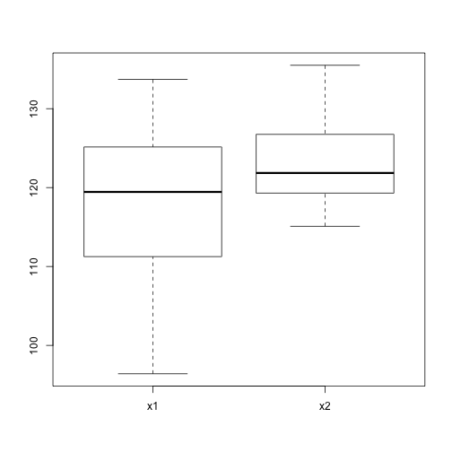

```r
x1 <- c(125.3, 101, 117.2, 133.7, 96.4, 124.5, 118.7, 106.2, 116.3, 120.2, 125, 128.8)
x2 <- c(127.3, 120.2, 126.2, 125.4, 115.1, 118.5, 135.5, 118.2, 122.9, 120.1, 120.8, 130.7)

df <- data.frame(cbind(x1,x2))
boxplot(df)
```

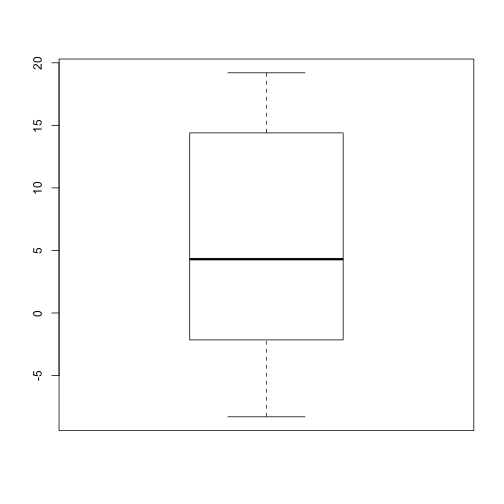

```r
boxplot(x2-x1)
```

```r
wilcox.test(x1,x2, paired=T, alternative="less")
```

```
##
##  Wilcoxon signed rank test
##
## data:  x1 and x2
## V = 17, p-value = 0.04614
## alternative hypothesis: true location shift is less than 0
```

```r
wilcox.test(x1 - x2, alternative="less")
```

```
##
##  Wilcoxon signed rank test
##
## data:  x1 - x2
## V = 17, p-value = 0.04614
## alternative hypothesis: true location is less than 0
```

```r
wilcox.test(x2 - x1, alternative="greater")
```

```
##
##  Wilcoxon signed rank test
##
## data:  x2 - x1
## V = 61, p-value = 0.04614
## alternative hypothesis: true location is greater than 0
```

H0 is rejected at the 5% significance level.

**Q4.4.** Some physiological test measurements were conducted on 9 patients taken at the first (x) and second (y) visits after initiation of a therapy. Do you have enough evidence to reject H0 that the therapy did not work if it was intended to lower that physiological parameter?

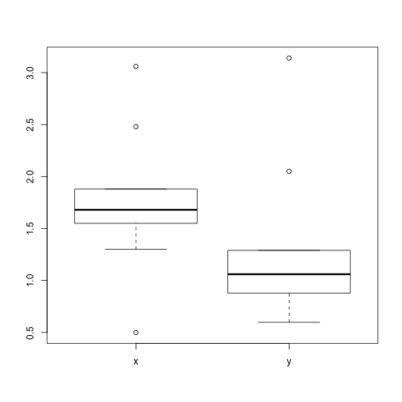

```r
x <- c(1.83,  0.50,  1.62,  2.48, 1.68, 1.88, 1.55, 3.06, 1.30)
y <- c(0.878, 0.647, 0.598, 2.05, 1.06, 1.29, 1.06, 3.14, 1.29)
df <- data.frame(cbind(x,y))
boxplot(df)
```

```r
wilcox.test(y-x, alternative = "less")
```

```
##
##  Wilcoxon signed rank test
##
## data:  y - x
## V = 5, p-value = 0.01953
## alternative hypothesis: true location is less than 0
```

H0 is rejected at the 5% significance level (p-value < 0.02).

### 4.3. Two independent sample Mann-Whitney-Wilcoxon test on ranks.

(the test runs with continuity correction by default, can be switched off). H0: samples come from the same population.

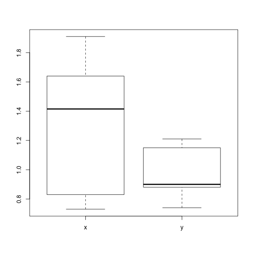

```r
x <- c(0.80, 0.83, 1.89, 1.04, 1.45, 1.38, 1.91, 1.64, 0.73, 1.46)
y <- c(1.15, 0.88, 0.90, 0.74, 1.21)

df <- data.frame(cbind(x,y))
boxplot(df)
```

```r
wilcox.test(x, y, alternative = "greater")
```

```
##
##  Wilcoxon rank sum test
##
## data:  x and y
## W = 35, p-value = 0.1272
## alternative hypothesis: true location shift is greater than 0
```

There is no enough evidence to reject H0 at the 5% significance level.